# Chapter 03 Exercises

## 3.7 Exercises

1. Consider the GDP information in `global_economy`. Plot the GDP per capita for each country over time. Which country has the highest GDP per capita? How has this changed over time?

```
## `mutate_if()` ignored the following grouping variables:
## Column `Country`
```

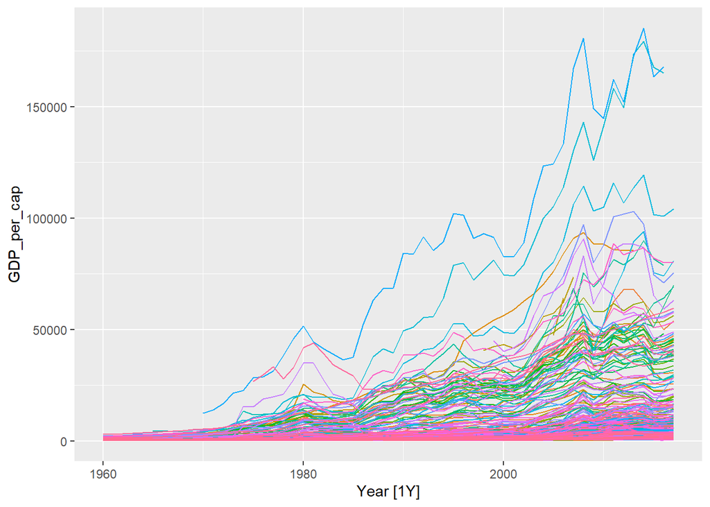

```r
global_GDP_per_cap <- global_economy %>%
  mutate(GDP_per_cap = GDP/Population) %>%
  select(Country, Year, GDP_per_cap) %>%
  group_by(Country)


autoplot(global_GDP_per_cap, GDP_per_cap) +
  theme(legend.position="none")
```

```r
global_GDP_per_cap %>%
  filter(Year == 2017) %>%
  arrange(desc(GDP_per_cap))
```

```
## # A tsibble: 262 x 3 [1Y]
## # Key:       Country [262]
## # Groups:    Country [262]
##    Country           Year GDP_per_cap
##    <fct>            <dbl>       <dbl>
##  1 Luxembourg        2017     104103.
##  2 Macao SAR, China  2017      80893.
##  3 Switzerland       2017      80190.
##  4 Norway            2017      75505.
##  5 Iceland           2017      70057.
##  6 Ireland           2017      69331.
##  7 Qatar             2017      63249.
##  8 United States     2017      59532.
##  9 North America     2017      58070.
## 10 Singapore         2017      57714.
## # ... with 252 more rows
```

2. For each of the following series, make a graph of the data. If transforming seems appropriate, do so and describe the effect.
- United States GDP from `global_economy`

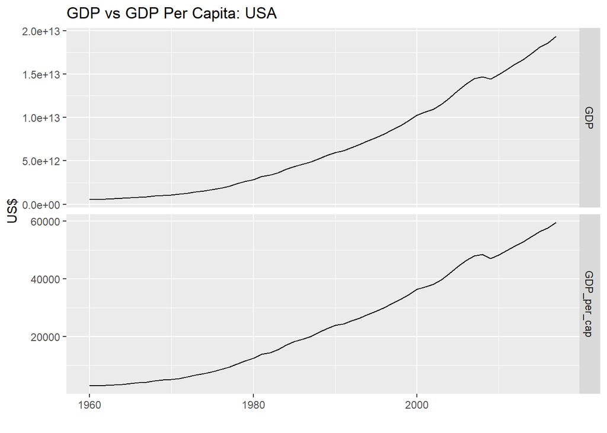

```r
global_economy %>%
  mutate(GDP_per_cap = GDP/Population) %>%
  select(Country, Year, GDP, GDP_per_cap) %>%
  filter(Country == 'United States') %>%
  pivot_longer(c(GDP, GDP_per_cap),
               values_to = 'GDP') %>%
  ggplot(aes(x=Year, y=GDP)) +
  geom_line() +
  facet_grid(name ~ ., scales='free_y') +
  labs(y='US$',
       x='',
       title='GDP vs GDP Per Capita: USA')
```

I assumed that a population transformation would make sense here, but the graph did not change much besides the y-axis scale.

- Slaughter of Victorian “Bulls, bullocks and steers” in `aus_livestock`

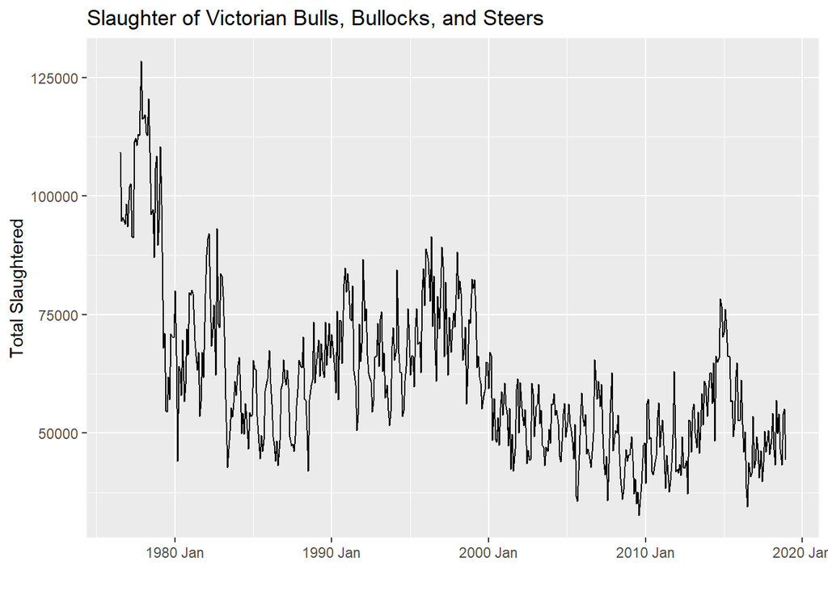

```r
victorian_bulls <- aus_livestock %>%
  filter(Animal == 'Bulls, bullocks and steers' & State == 'Victoria')

autoplot(victorian_bulls,Count) +
  labs(y='Total Slaughtered',
      x='',
      title='Slaughter of Victorian Bulls, Bullocks, and Steers')
```

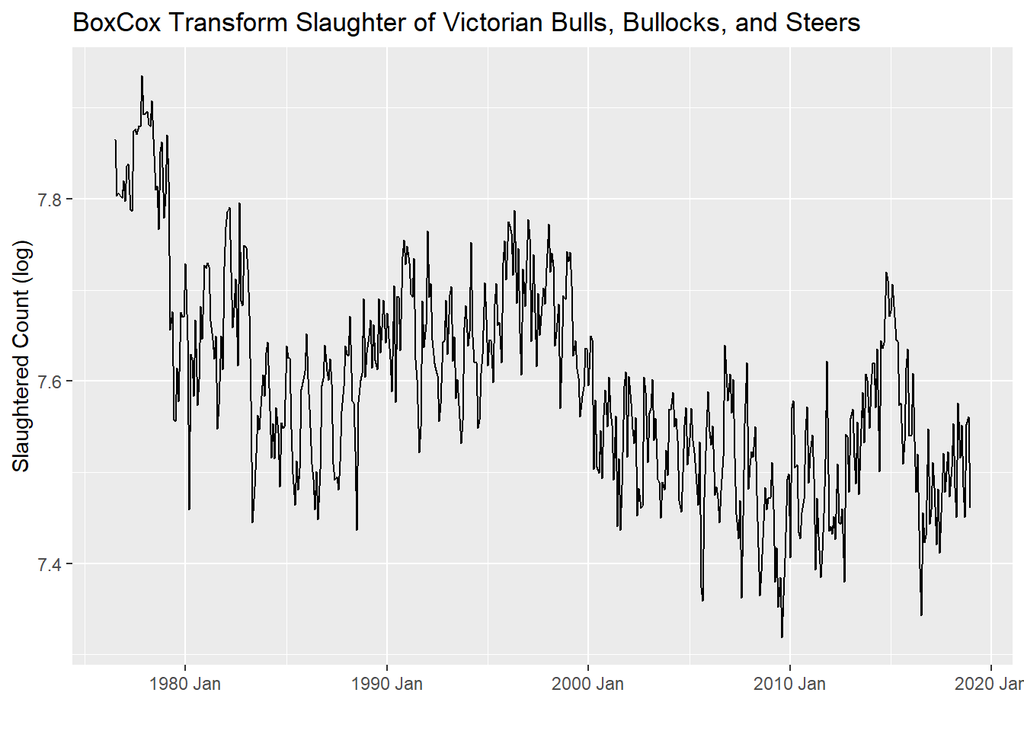

```r
# box cox transformation

lambda <- victorian_bulls %>%
  features(Count, features = guerrero) %>%
  pull(lambda_guerrero)

victorian_bulls %>%
  autoplot(box_cox(Count, lambda)) +
  labs(y='Slaughtered Count (log)',
       x='',
       title='BoxCox Transform Slaughter of Victorian Bulls, Bullocks, and Steers')
```

Box-cox performed here to make the variation over time more consistent

- Victorian Electricity Demand from `vic_elec.`

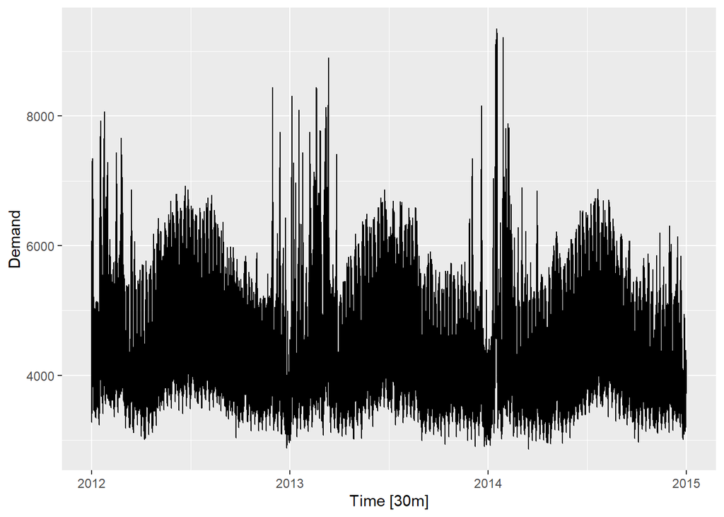

```r
autoplot(vic_elec, Demand)
```

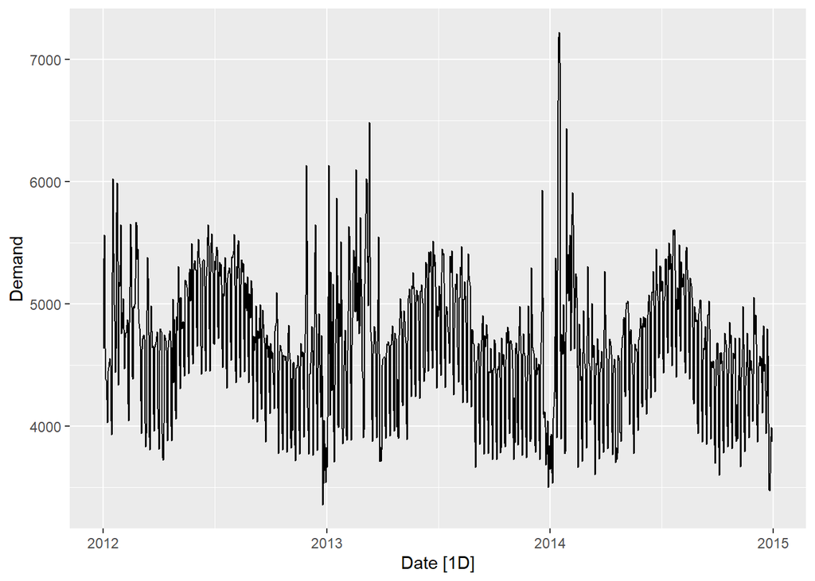

```r
avg_elec_demand_daily <- aggregate(vic_elec['Demand'], by=vic_elec['Date'], mean)

avg_elec_demand_daily %>%
  as_tsibble(index=Date) %>%
  autoplot(Demand)
```

Transforming from half hour increments to the average daily makes the graph more readable and the data easier to work with while retaining its shape. Could also potentially use a box_cox transform

- Gas production from `aus_production`

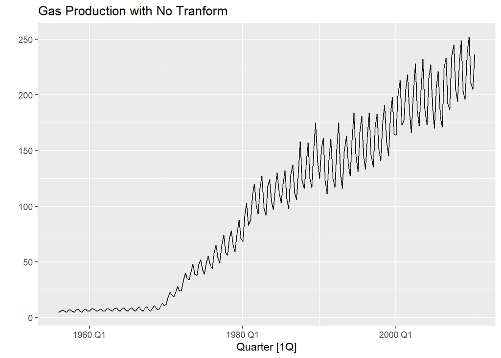

```r
autoplot(aus_production, Gas)+
  labs(y='',
       title='Gas Production with No Tranform')
```

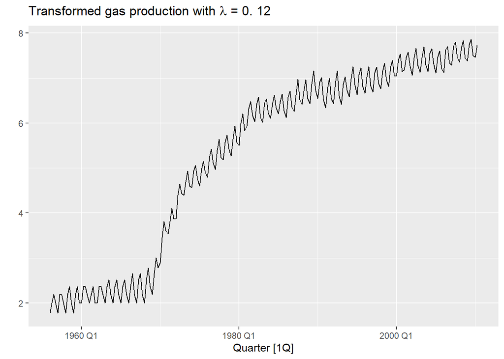

```r
lambda <- aus_production %>%
  features(Gas, features = guerrero) %>%
  pull(lambda_guerrero)
aus_production %>%
  autoplot(box_cox(Gas, lambda)) +
  labs(y = "",
       title = latex2exp::TeX(paste0(
         "Transformed gas production with $\\lambda$ = ",
         round(lambda,2))))
```

Variance over time has been standardized with Box Cox tranform

3. Why is a Box-Cox transformation unhelpful for the `canadian_gas` data?

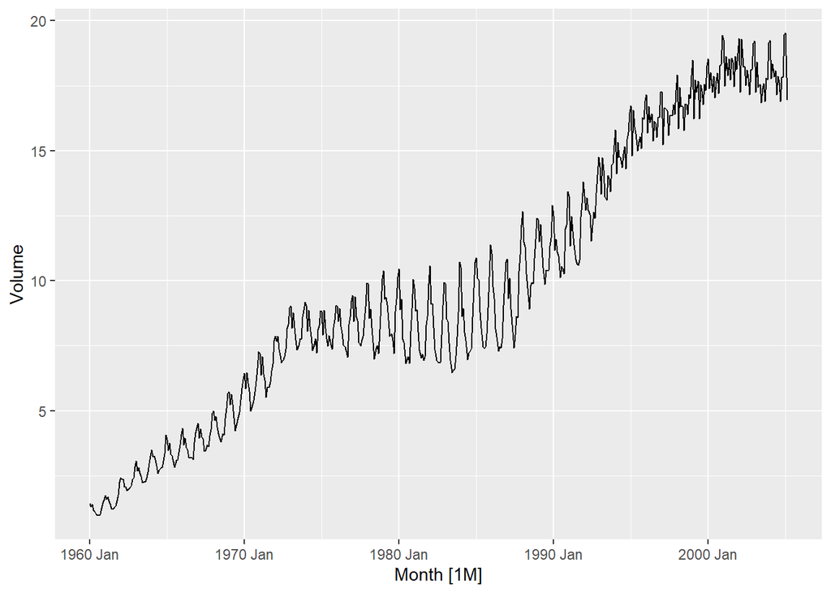

```r
autoplot(canadian_gas, Volume)
```

While the variance changes over time, variance does not increase consistently over time with the increase in level. Variance increases and then decreases around 1991.

4. What Box-Cox transformation would you select for your retail data (from Exercise 8 in Section 2.10

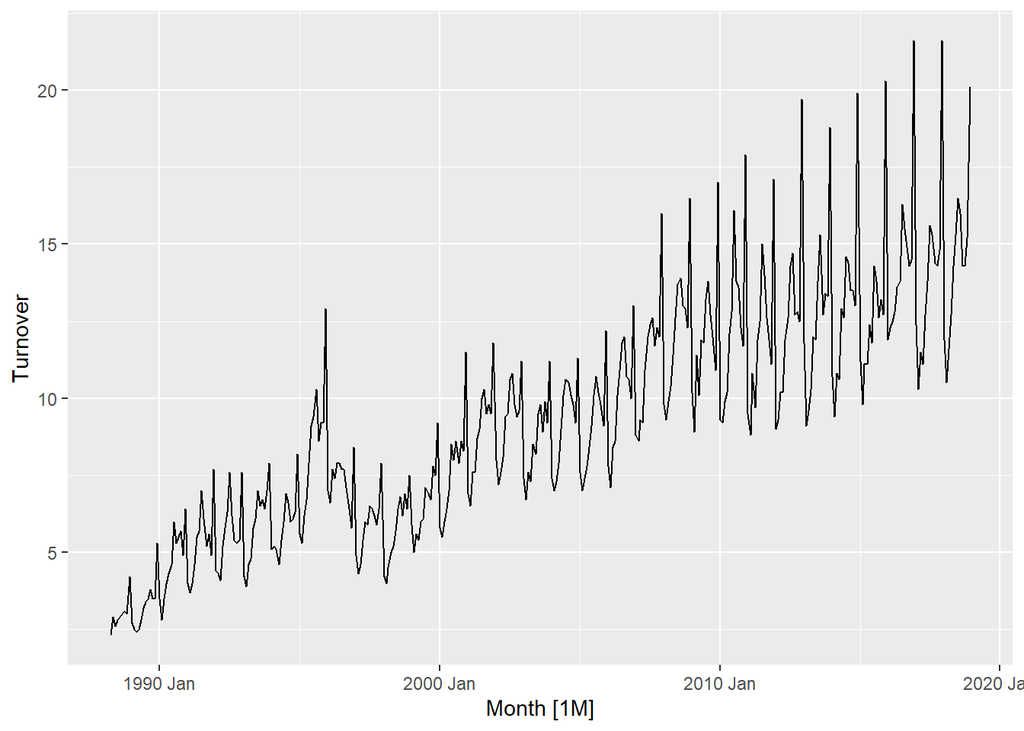

```r
set.seed(12345678)
myseries <- aus_retail %>%
  filter(`Series ID` == sample(aus_retail$`Series ID`,1))

autoplot(myseries, Turnover)
```

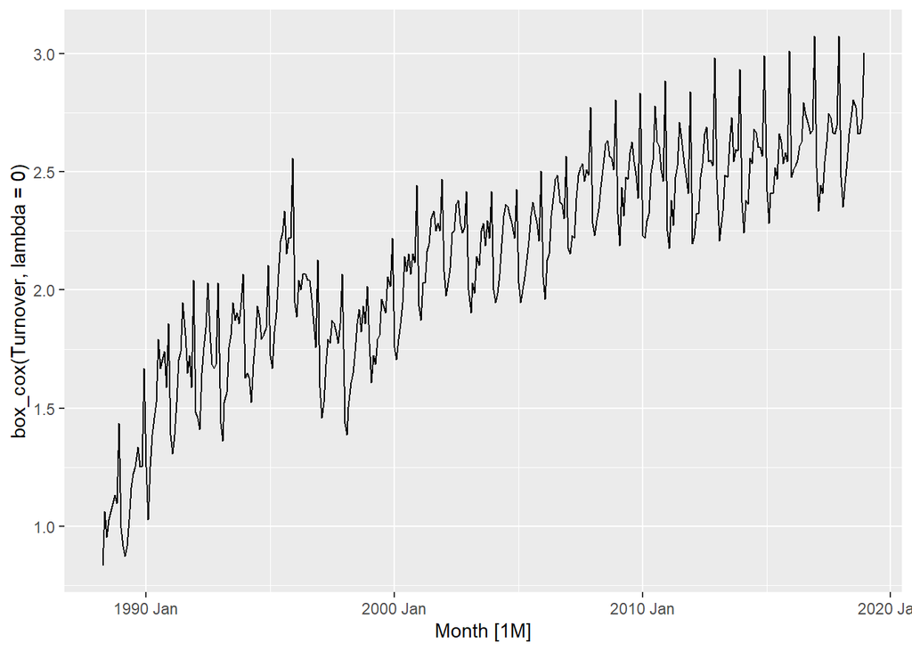

```r
myseries %>%
  autoplot(box_cox(Turnover, lambda=0))
```

If I had to choose a lambda manually between 0 and 1, I would choose the natural log or 0 for this series, though a power calculation using .1 also seems to make the series more consistent.

5. For the following series, find an appropriate Box-Cox transformation in order to stabilise the variance. Tobacco from `aus_production`, Economy class passengers between Melbourne and Sydney from `ansett`, and Pedestrian counts at Southern Cross Station from `pedestrian`.

I’m only going to be doing one of these since it is the same code for every box_cox

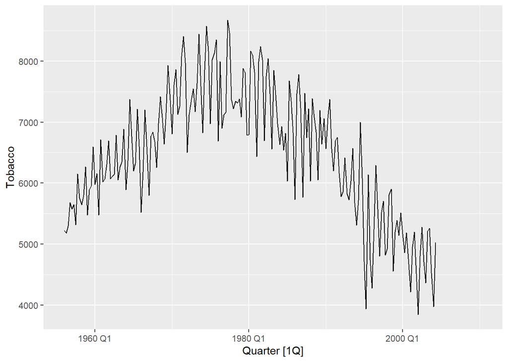

```r
autoplot(aus_production, Tobacco)
```

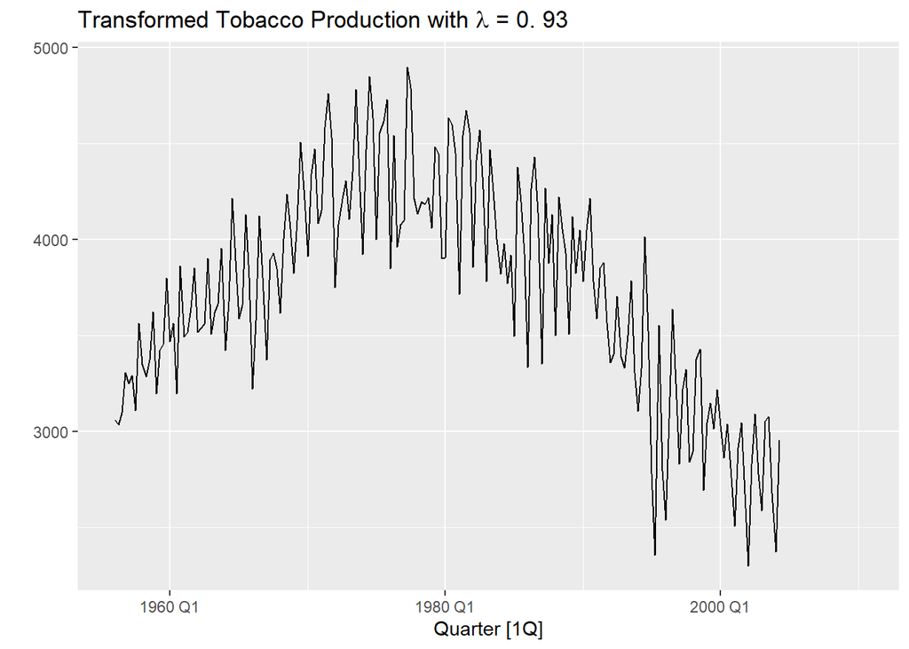

```r
lambda <- aus_production %>%
  features(Tobacco, features = guerrero) %>%
  pull(lambda_guerrero)
aus_production %>%
  autoplot(box_cox(Tobacco, lambda)) +
  labs(y = "",
       title = latex2exp::TeX(paste0(
         "Transformed Tobacco Production with $\\lambda$ = ",
         round(lambda,2))))
```

6. Show that a 3×5MA is equivalent to a 7-term weighted moving average with weights of 0.067, 0.133, 0.200, 0.200, 0.200, 0.133, and 0.067.

```r
apple_stock <- gafa_stock %>%
  select(Adj_Close) %>%
  filter(Symbol == "AAPL" & year(Date) == 2014)

apple_stock %>%
  head(7) %>%
  mutate(
    `5-MA` = slider::slide_dbl(Adj_Close, mean, .before=2, .after=2, .complete=TRUE),
    `3x5-MA` = slider::slide_dbl(`5-MA`, mean, .before=1, .after=1, .complete=TRUE)
  )
```

```
## # A tsibble: 7 x 5 [!]
## # Key:       Symbol [1]
##   Adj_Close Date       Symbol `5-MA` `3x5-MA`
##       <dbl> <date>     <chr>   <dbl>    <dbl>
## 1      67.0 2014-01-02 AAPL     NA       NA
## 2      65.5 2014-01-03 AAPL     NA       NA
## 3      65.9 2014-01-06 AAPL     65.9     NA
## 4      65.4 2014-01-07 AAPL     65.5     65.6
## 5      65.8 2014-01-08 AAPL     65.3     NA
## 6      65.0 2014-01-09 AAPL     NA       NA
## 7      64.5 2014-01-10 AAPL     NA       NA
```

This is how to construct a 3x5MA, but I’m unsure how to prove the weights.

7. Consider the last five years of the Gas data from `aus_production`.
   1. Plot the time series. Can you identify seasonal fluctuations and/or a trend-cycle?
   2. Use classical_decomposition with type=multiplicative to calculate the trend-cycle and seasonal indices.
   3. Do the results support the graphical interpretation from part a?
   4. Compute and plot the seasonally adjusted data.
   5. Change one observation to be an outlier (e.g., add 300 to one observation), and recompute the seasonally adjusted
   6. data. What is the effect of the outlier?
   7. Does it make any difference if the outlier is near the end rather than in the middle of the time series?

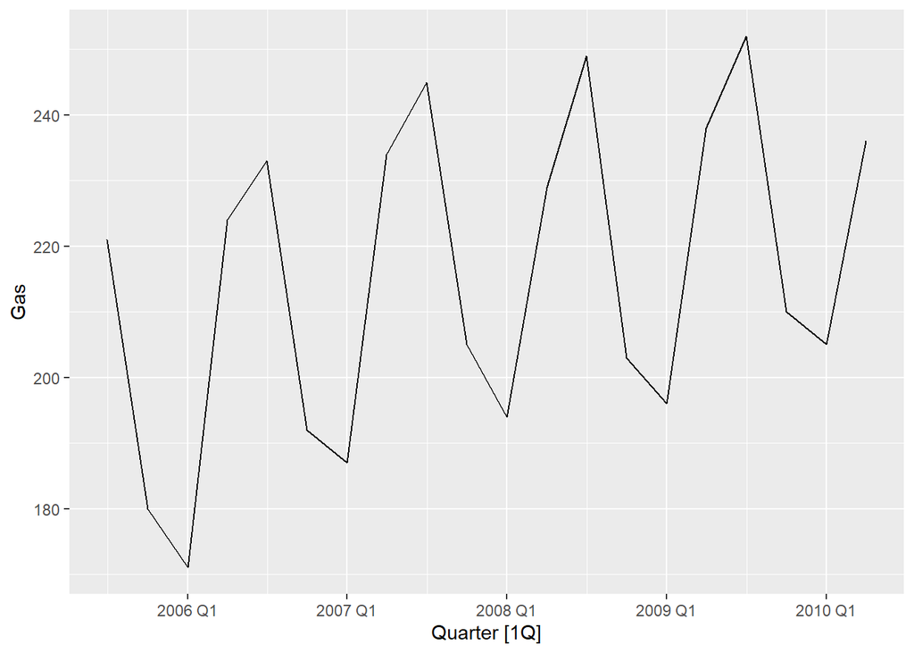

```r
gas <- tail(aus_production, 5*4) %>%
  select(Gas) # data is quarterly hence the suggested "5 X 4" for 5 yrs

autoplot(gas, Gas)
```

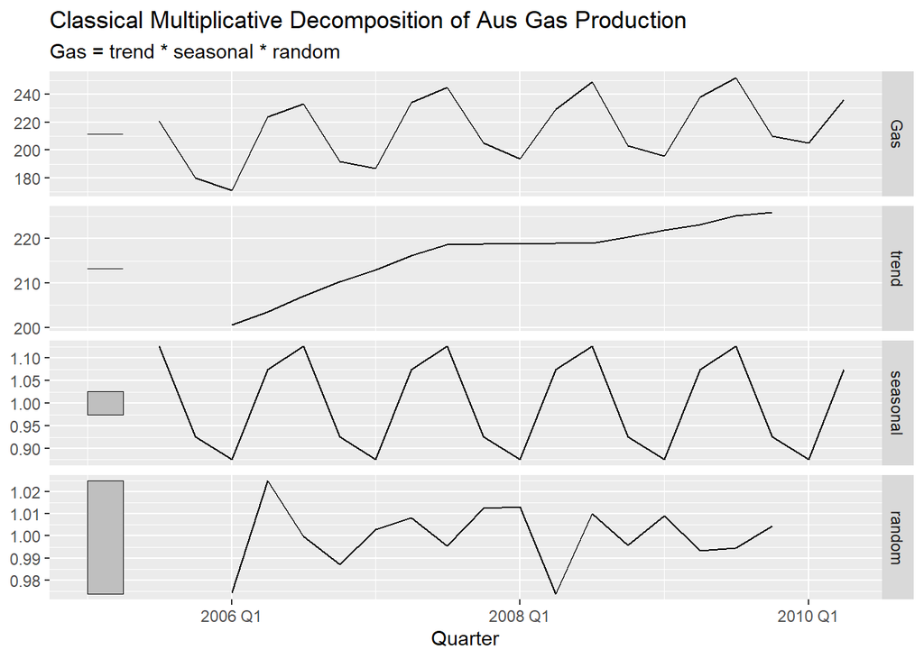

```r
# Classical multiplicative decomp
gas %>%
  model(
    classical_decomposition(Gas, type = 'multiplicative')
  ) %>%
  components() %>%
  autoplot() +
  labs(title = 'Classical Multiplicative Decomposition of Aus Gas Production')
```

Results of the decomp seem to support the conclusions for part a

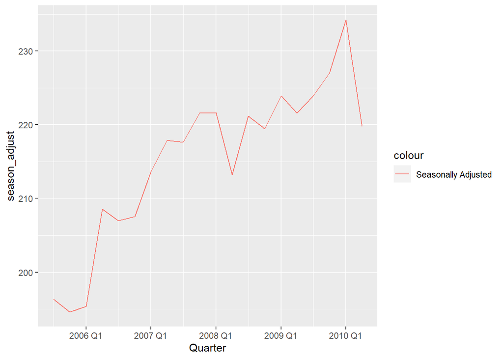

```r
# plotting seasonally adjusted component
gas %>%
  model(
    classical_decomposition(Gas, type = 'multiplicative')
  ) %>%
  components() %>%
  ggplot(aes(x=Quarter)) +
  geom_line(aes(y = season_adjust,
                colour = "Seasonally Adjusted"))
```

```r
# adding 300 to an observation

gas$Gas[[10]] <- gas$Gas[[10]] + 300
```

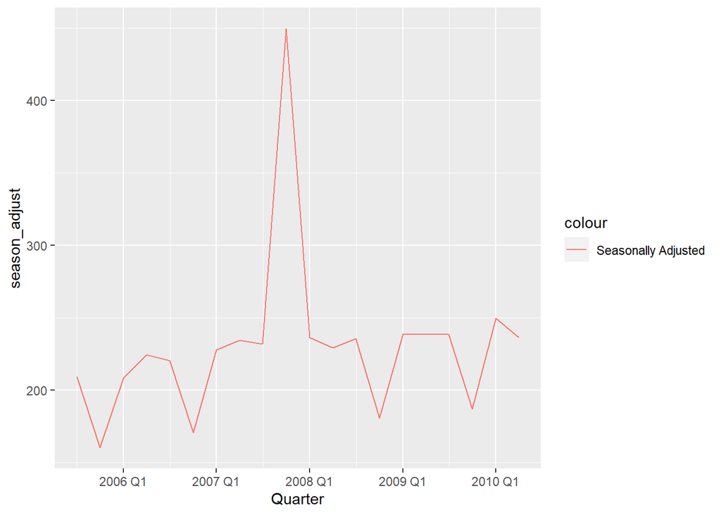

```r
gas %>%
  model(
    classical_decomposition(Gas, type = 'multiplicative')
  ) %>%
  components() %>%
  ggplot(aes(x=Quarter)) +
  geom_line(aes(y = season_adjust,
                colour = "Seasonally Adjusted"))
```

8. Recall your retail time series data (from Exercise 8 in Section 2.10). Decompose the series using X-11. Does it reveal any outliers, or unusual features that you had not noticed previously?

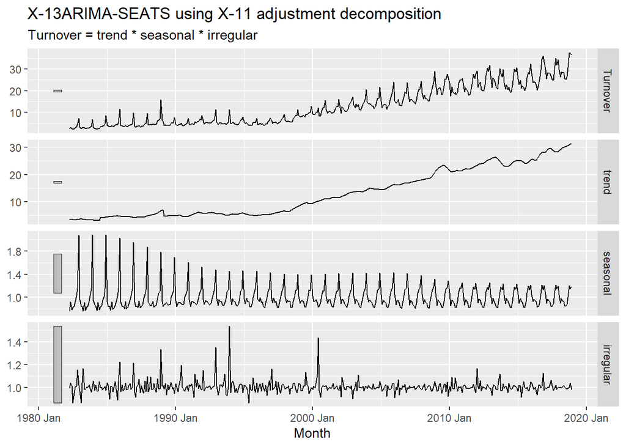

```r
set.seed(222)
myseries <- aus_retail %>%
  filter(`Series ID` == sample(aus_retail$`Series ID`,1))


myseries %>%
  model(x11 = X_13ARIMA_SEATS(Turnover ~ x11())) %>%
  components() %>%
  autoplot()
```

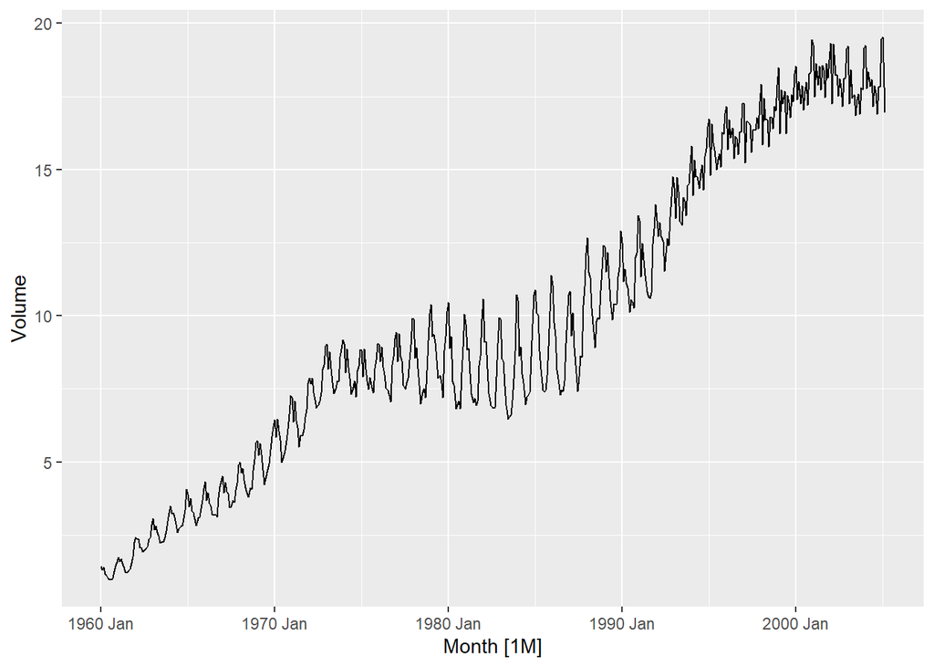

```r
autoplot(canadian_gas, Volume)
```

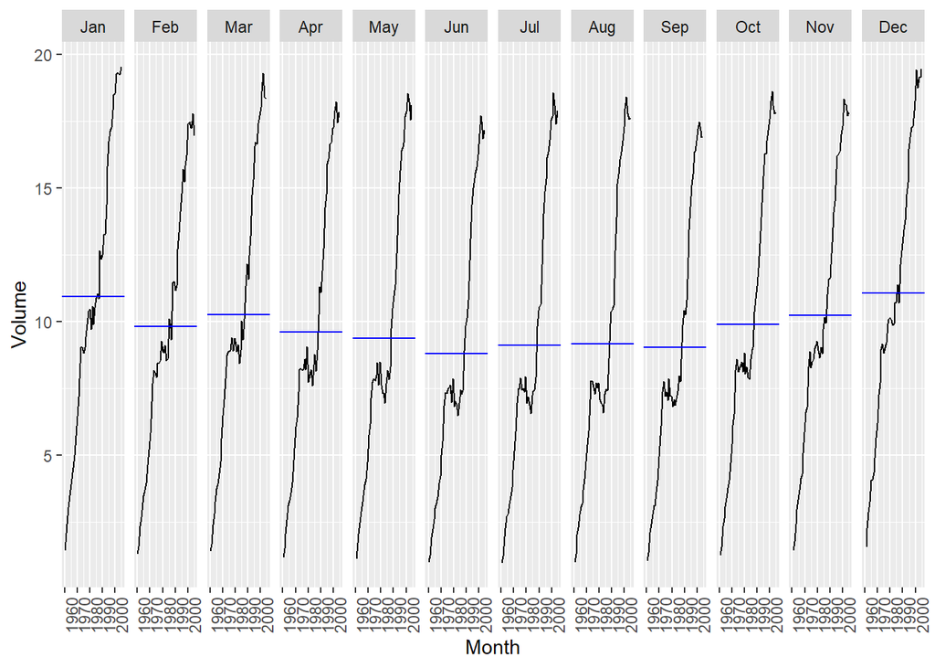

```r
gg_subseries(canadian_gas, Volume)
```

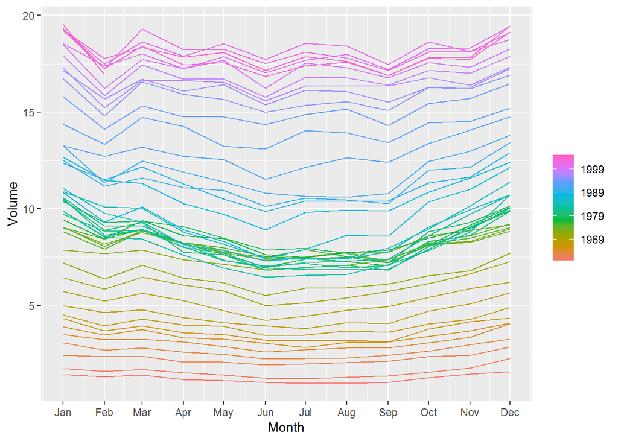

```r
gg_season(canadian_gas, Volume)
```

Variance of the data fluctuates over time. Subseries plot shows lagging volume in the 70’s and 80s before continuing its upward trend.

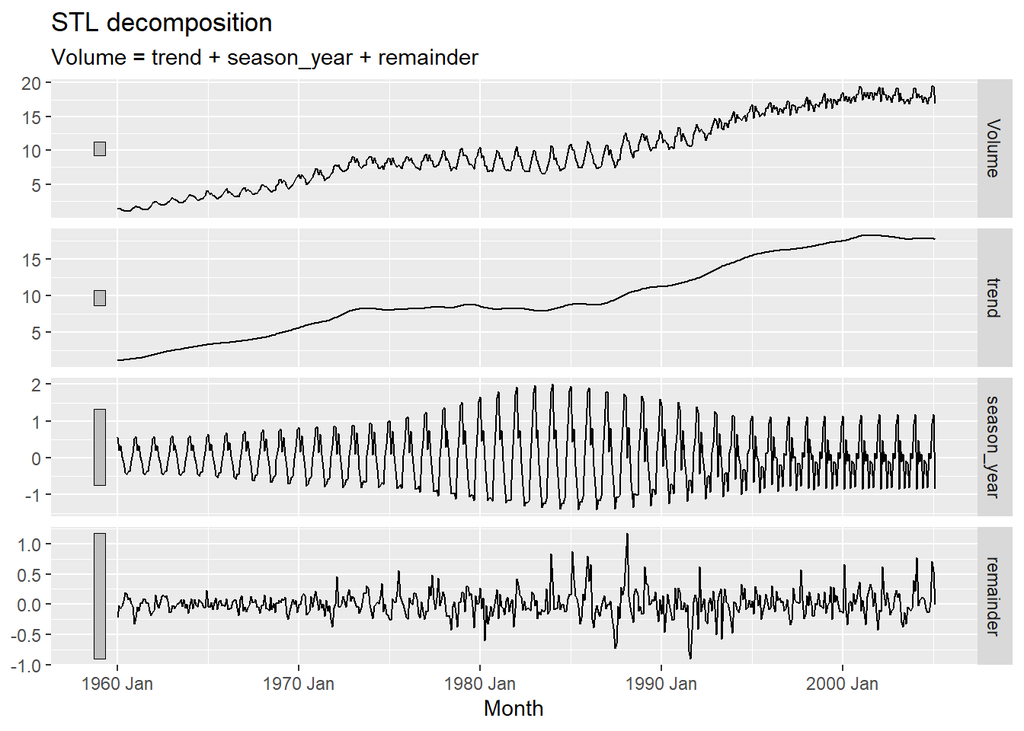

```r
canadian_gas %>%
  model(STL(Volume ~ trend(window = 21) +
              season(window=12),
            robust = TRUE)) %>%
  components() %>%
  autoplot()
```

We can see seasonal shifts over time

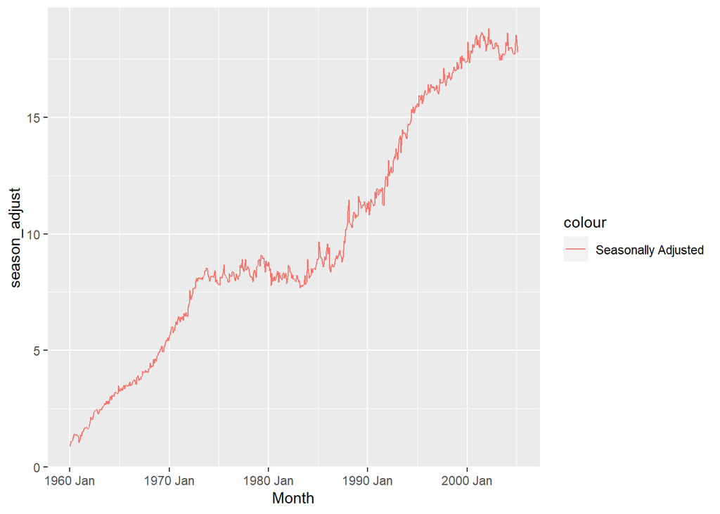

```r
canadian_gas %>%
  model(STL(Volume ~ trend(window = 21) +
              season(window=12),
            robust = TRUE)) %>%
  components() %>%
  ggplot(aes(x=Month)) +
  geom_line(aes(y = season_adjust,
                colour = "Seasonally Adjusted"))
```

Above is a plausible seasonally adjusted series

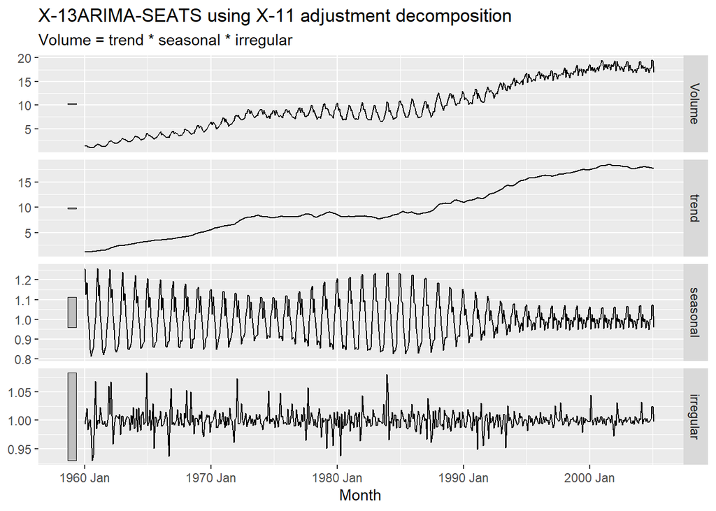

```r
canadian_gas %>%
  model(x11 = X_13ARIMA_SEATS(Volume ~ x11())) %>%
  components() %>%
  autoplot()
```

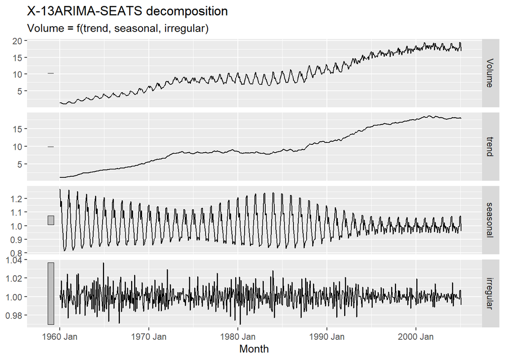

```r
canadian_gas %>%
  model(seats = X_13ARIMA_SEATS(Volume ~ seats())) %>%
  components() %>%
  autoplot()
```

I think the X-11 does a better job than the SEATS or STL decomp. It picks up on the fluctuation of seasonality and the residual appears to have less white noise.